# Capstone Milestone Report

Lakshmy Priya

20 March 2016

# Introduction

This goal of this project is to analyze a large corpus of text to understand the language structures and to build a predictive text model. This Milestone Report will cover the initial stages of loading, cleaning and exploring the text data.

## Loading the Data

The data is loaded from https://d396qusza40orc.cloudfront.net/dsscapstone/dataset/Coursera-SwiftKey.zip . The three sources of text come from Twitter, Blogs and News.

Summary of source data:

```
## [1] "en_US.blogs.txt"   "en_US.news.txt"    "en_US.twitter.txt"
```

```
##      files     size in MB lines
## [1,] "Twitter" "159.36"   "2360148"
## [2,] "Blogs"   "200.42"   "899288"
## [3,] "News"    "196.28"   "77259"
```

## Pre-Processing the Data

The following steps were taken to sample and pre-process the large amounts of text from the original datasets to build a smaller corpus that was easy and quick to work with

1. Sampling & Merging : A random sample of 5000 lines per source was extracted and combined into one dataset of 15000 lines
2. Special Characters : All non-ASCII characters were removed.
3. Removing Numbers & Punctuation & Lower CAse : Using the tm package, numbers & punctuation were removed and all words were converted to lower case.
4. Profanity filtering : The final corpus had a list of profane words removed from it. See References for source of words.
5. Stemming : The corpus was then stemmed to make sure all formats of the same root word would be counted in the same way.

An illustration of the cleaning process:

```r
# Original text
samples[55]
```

```
## [1] "\"Within 15 minutes the guy came out and said, Oh my God, this is a clear case of embezzlement, \" said Blake, 76, adding the theft was pegged at about $30,000."
```

```r
# After cleaning out numbers, special characters and punctuation
corpustext[[55]]$content
```

```
## [1] "within minutes the guy came out and said oh my god this is a clear case of embezzlement said blake adding the theft was pegged at about "
```

```r
# After stemming
corpstem[[55]]$content
```

```
## [1] "within minut the guy came out and said oh my god this is a clear case of embezzl said blake ad the theft was peg at about"
```

## Exploratory Data Analysis

After pre-processing we build a Term Document Matrix from the corpus of clean data in order to be able to break up our data into blocks of 1-word, 2-word and 3-word tokens. This allows us to analyze the data and run frequency reports in an easy way to understand the distribution of words and relationship between them.

```
## <<DocumentTermMatrix (documents: 15000, terms: 3275)>>
## Non-/sparse entries: 247430/48877570
## Sparsity           : 99%
## Maximal term length: 13
## Weighting          : term frequency (tf)
```

```
## <<TermDocumentMatrix (terms: 5, documents: 5)>>
## Non-/sparse entries: 0/25
## Sparsity           : 100%
## Maximal term length: 7
## Weighting          : term frequency (tf)
##
##          Docs
## Terms     character(0) character(0) character(0) character(0) character(0)
##   abandon            0            0            0            0            0
##   abil               0            0            0            0            0
##   abl                0            0            0            0            0
##   about              0            0            0            0            0
##   abov               0            0            0            0            0
```

Once we have the data in the Document Term Matrix format, we can plot out the most frequent words in the corpus.

We currently have 3275 unique ‘words’ in our corpus after taking in only word-stems that occur at least 10 times in 15000 lines, stemming and before removing non-English words and correcting spellings. We believe this number should cover most of the commonly used words in day to day communication in English. Based on this source, “a vocabulary of just 3000 words provides coverage for around 95% of common texts.” http://www.lingholic.com/how-many-words-do-i-need-to-know-the-955-rule-in-language-learning-part-2/

```
## [1] 15000  3275
```

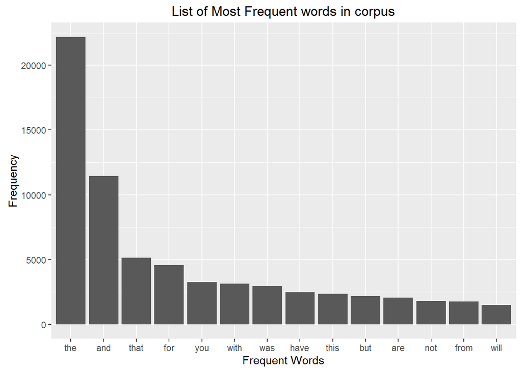

## Steps towards Prediction

To set up the data to be able to predict the next word, we split up the words into tokens of 2-word and 3-word phrases.

```r
ThreeWordTokens <- function(x) NGramTokenizer(x, Weka_control(min=3, max =3))
Threewords <- TermDocumentMatrix(corpstem, control = list(tokenize = ThreeWordTokens, bounds = list(global = c(5,Inf) )))
findFreqTerms(Threewords, lowfreq = 50)
```

```
##  [1] "a lot of"       "as well as"     "be abl to"      "end of the"
##  [5] "go to be"       "i want to"      "is go to"       "it was a"
##  [9] "one of the"     "out of the"     "part of the"    "some of the"
## [13] "the end of"     "the fact that"  "the rest of"    "the unit state"
## [17] "there is a"     "to be a"
```

```r
TwoWordTokens <- function(x) NGramTokenizer(x, Weka_control(min=2, max =2))

Twowords <- TermDocumentMatrix(corpstem, control = list(tokenize = TwoWordTokens, bounds = list(global = c(5,Inf))))
findFreqTerms(Twowords, lowfreq = 150)
```

```
##  [1] "a few"     "a great"   "a littl"   "a lot"     "about the"
##  [6] "all the"   "and a"     "and i"     "and it"    "and the"
## [11] "and then"  "as a"      "as the"    "at the"    "be a"
## [16] "but i"     "but it"    "by the"    "for a"     "for the"
## [21] "from the"  "go to"     "had a"     "has been"  "have a"
## [26] "have been" "have to"   "he said"   "he was"    "i am"
## [31] "i dont"    "i had"     "i have"    "i love"    "i think"
## [36] "i was"     "if you"    "in a"      "in my"     "in the"
## [41] "into the"  "is a"      "is not"    "is the"    "it a"
## [46] "it is"     "it was"    "lot of"    "more than" "need to"
## [51] "of a"      "of his"    "of my"     "of the"    "on a"
## [56] "on the"    "one of"    "out of"    "over the"  "part of"
## [61] "that i"    "that is"   "that the"  "the first" "the most"
## [66] "the new"   "the same"  "the world" "there are" "there is"
## [71] "they are"  "this is"   "to a"      "to be"     "to do"
## [76] "to get"    "to have"   "to make"   "to see"    "to the"
## [81] "tri to"    "want to"   "was a"     "was the"   "we are"
## [86] "when i"    "will be"   "with a"    "with the"  "would be"
## [91] "you can"   "you have"
```

## Next Steps and Known Issues

- Processing time is relatively quick as we are using a subset of the full data. If future steps are quick enough, data sampling can be amped up to reflect the full set better.
- A smaller sample size may affect the accuracy and scalability of the analysis
- As I’m currently working with a sample sub-set of the full data available on the 3 mediums, I can set aside another dataset to test my prediction on that is separate from the sample I am modelling with. This could avoid over-fitting.
- Currently unsure of the usefulness of stemming and the implications of this on the prediction algorithm.
- Stop words and frequently occuring words like ‘to’, ‘the’, ‘and’ will not be removed as these are important to predict to make text inputs easier.

# References

1. Basic Text Mining in R : https://rstudio-pubs-static.s3.amazonaws.com/31867_8236987cf0a8444e962ccd2aec46d9c3.html#stage-the-data
2. Profanity List : http://www.frontgatemedia.com/a-list-of-723-bad-words-to-blacklist-and-how-to-use-facebooks-moderation-tool/
3. http://handsondatascience.com/TextMiningO.pdf